# Biscuit Bonanza

Alexander Pil Henriksen

2023-09-28

## Intro

Once again we have taken it upon us in the Brunak Group to find out which among many products is the best and most praise-worthy. This time we look to the biscuits, treats that we all know and love, but which come in so many different varieties that it can be difficult to choose a box from the store without suffering mild vertigo. Furtunately, we have tasted and rated 9 different biscuits so that you, I and all of humanity can know which is the best biscuit out there.

## Score overview

12 people scored the biscuits on a 1 - 9 scale. Generally, the distribution of the scores looks somewhat normally distributed, albeit with some bias towards higher scores. Also, people seem to give lower DUNKABILITY scores Perhaps this is a feature which is especially difficult to get right.

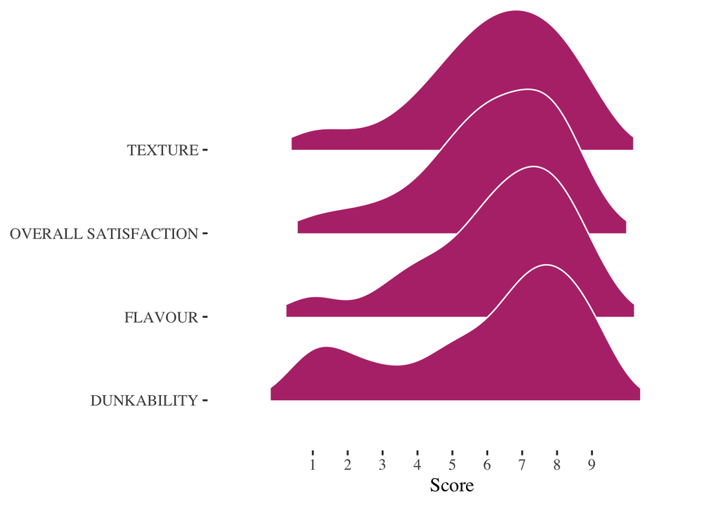

Some biscuits of course fare better than others. We can see that the Lotus Biscoff biscuit is very popular and it has the lowest variance of all the biscuits. Walker’s shortbread is not far behind with a slightly lower mean score and a slightly higher variance. However these two biscuits seem to be the clear winners.

```
## # A tibble: 9 × 4
##   Biscuit                                 mean   var votes
##   <chr>                                  <dbl> <dbl> <int>
## 1 Lotus Biscoff                           8     1       41
## 2 Walker's shortbread                     7.33  1.35    42
## 3 Cartwright sea salted caramel biscuits  6.56  2.88    39
## 4 LU Bastogne                             6.28  2.52    39
## 5 McVities Ginger Nuts                    6.23  4.66    43
## 6 Nutella Biscuit                         5.86  6.71    35
## 7 Sondey chocolate biscuits               5.59  5.89    34
## 8 Salling Digestive                       4.65  4.28    43
## 9 Sondey oatmeal cookies                  4.62  3.56    39
```

The picture is similar if we look into the various features of each biscuit. We can see that the Lotus Biscoff is actually the highest scoring biscuit across ALL features! Furthermore, there seems to be some consistency to the scores within each biscuit. So biscuits with a high FLAVOUR score generally also seem to have high DUNKABILITY scores for example. One exeption here is “Sondey chokolate biscuit” and “Nutella Biscuit” which have exceptionally low DUNKABILITY scores compared to their other features.

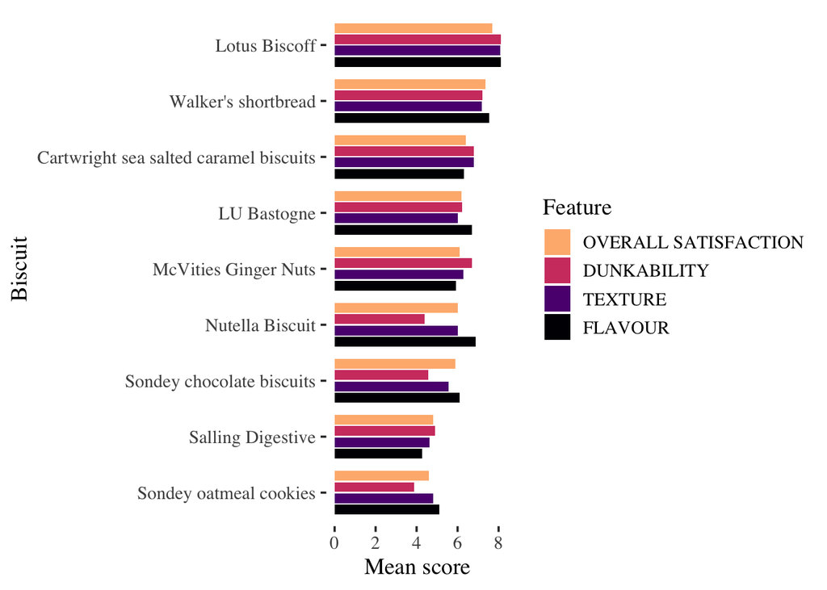

Lets look at some of the differences in the individual scores. Looking at OVERALL SATISFACTION there are big differences in response variability. Comparing the Lotus Biscoff to the Nutella Biscuit we see that although both of these were generally liked, the Lotus was liked by everyone while the Nutella Biscuit was absolutely not appreciated by a few.

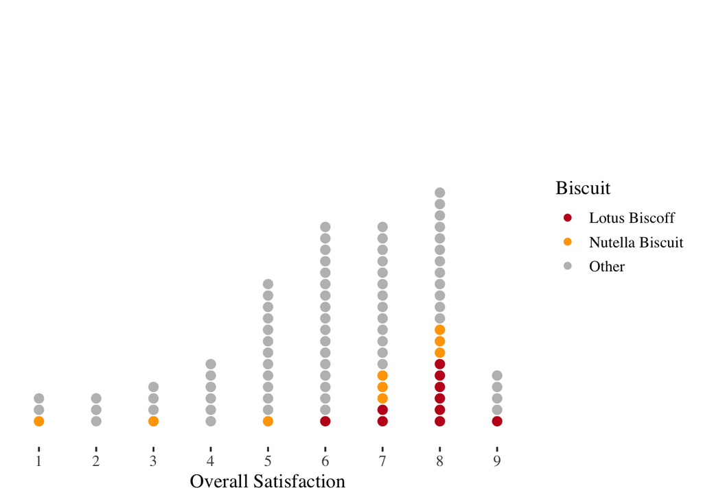

Below we see another example of varying opinions. Walker’s shortbread consistenly gets high scores in the DUNKABILITY feature. There are also people who think that the Sondey chocolate biscuits are very dunkable, but some REALLY don’t, leading to a very high variance in this biscuits DUNKABILITY scores.

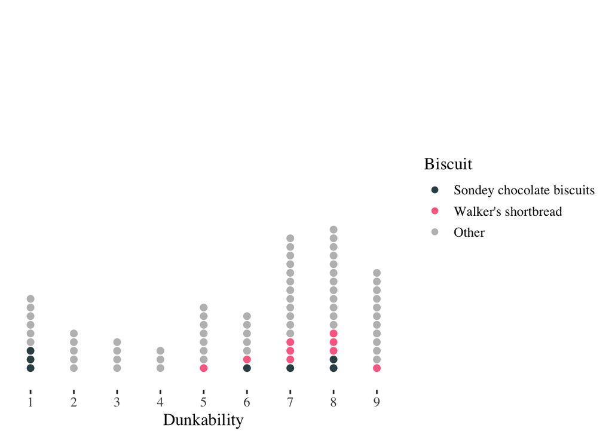

## Reviewer profiles

Instead of looking at the Biscuits in question let’s now turn our attention to the reviewers and their preferences. Below, we see the OVERALL SATISFACTION scores from two individuals who have similar tastes in biscuits. Apart from “Cartwright sea salted caramel biscuits” these two individuals seem to like the same biscuits.

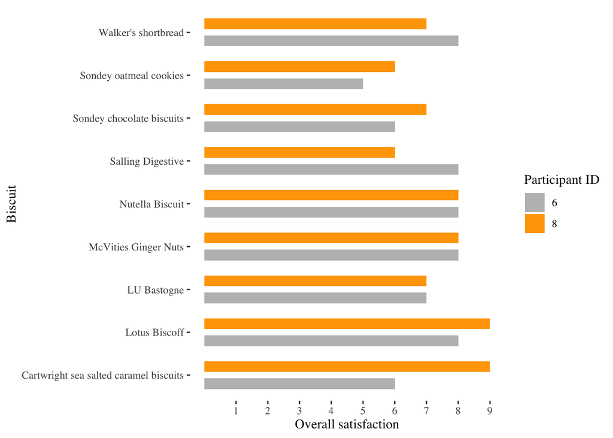

However, the similarities end here. If we instead look at the DUNKABILITY scores that these two individuals assigned the differences are suddenly bigger. They don’t agree on either the “Nutella Biscuit” or the “Lotus Biscoff” (which generally scored consistently). And individual nr 8 even refused to try dunking the “Sondey chocolate biscuits”.

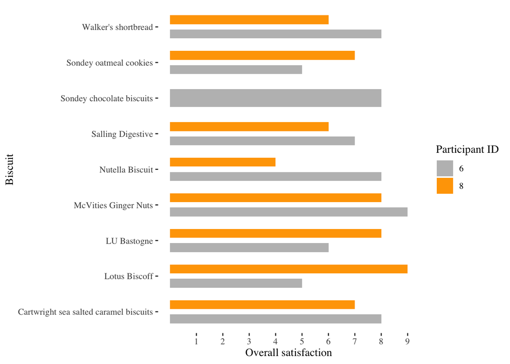

Let’s see which types of chips are most closely related in terms of reviewer ratings. Below we look at OVERALL SATISFACTION.

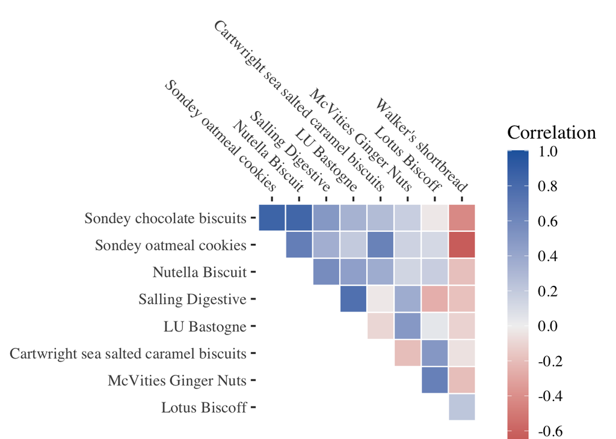

Here we see some interesting patterns. For example, it seems that Sondey’s biscuits are pleasing the same individuals as their chocolate biscuit and oatmeal cookies receive similar scores. On the other hand those that like Sondey’s products really don’t seem to agree with those that like Walker’s shortbread. Perhaps there are differences in the importance of brands at play here. Walker’s marketing is probably more targeted towards brand-consious consumers while Sondey is a broader brand with less of a specialized profile. Does this effect the ratings? Who knows, but its a hypothesis… Now let’s look at DUNKABILITY. Unsurprisingly, the Nutella Biscuit and Sondey’s chocolate biscuits have very similar scores. These are very similar biscuits and have similar qualities.

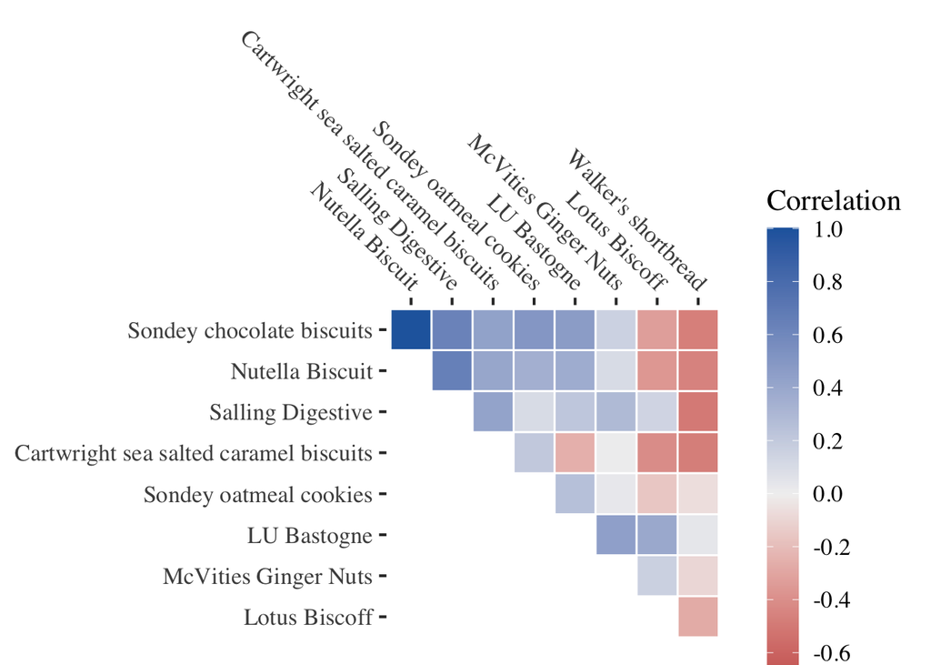

This result could suggest that at least in terms of DUNKABILITY, there is really no reason to choose the, probably more expensive, Nutella biscuit over Sondey’s generic version. But does the same hold true for FLAVOUR? Let’s find out.

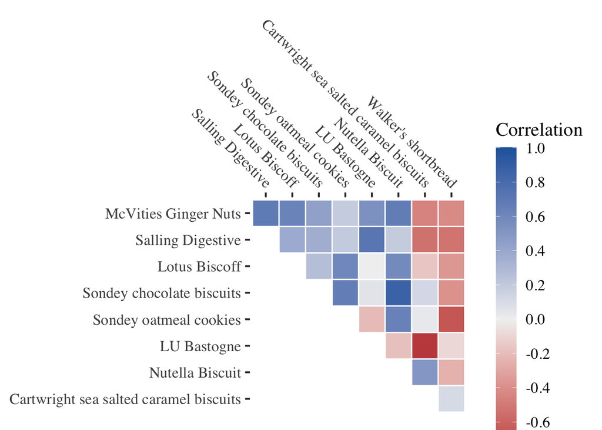

Here, we also see some interesting patterns. First of all we immediately notice the discrepancy between the ratings of LU Bastogne and Cartwright sea salted caramel biscuits. To the Brunak group palette these are, apparently, very different biscuits and few people seem to like or dislike both. We see a strong correlation between the Nutella biscuit and Sondey’s chocolate biscuit again hinting that perhaps the generic Sondey version is just as good. Surprisingly, there seems to be close to zero correlation between the LU Bastogne and the Lotus Biscoff, two biscuits which are otherwise quite similar in terms of the color, smell and flavour (cinnamon).

## Correlations

Lastly, lets see if any of our covariates effect the different scores. Perhaps not surprisingly, there were no effects of pet preference of sweet salty snacks on any measures features (Boring, I know…). But there were two effects that were significantly associated even after multiple testing correction (FDR). Namely, that male participants generally give higher ratings. This was not the case for all of the biscuits but was true when aggregating across all biscuits and was especially true for the LU Bastogne biscuit.

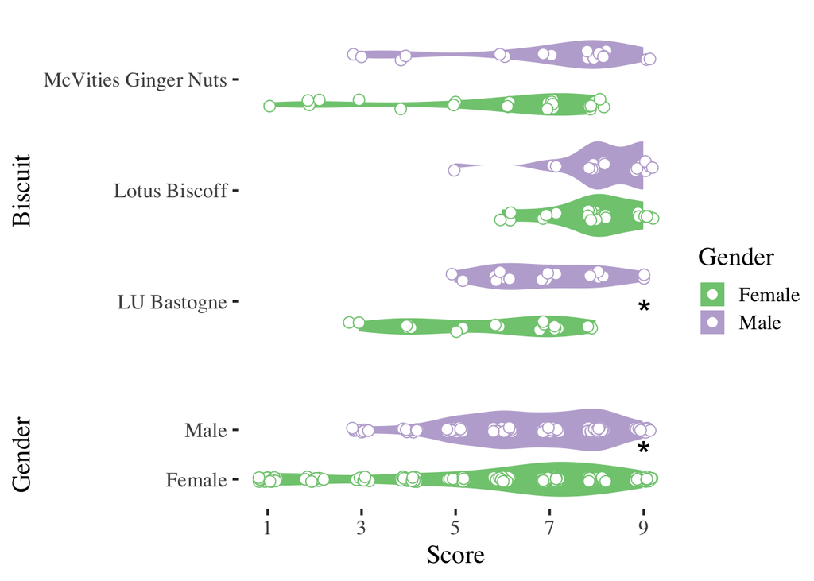

There were also effects that showed nominal significance and that may have been more strongly if we had included more subjects in the biscuit tasting. Interestingly, older individuals seem to give lower DUNKABILITY scores across all biscuits. As dunking a biscuit in a hot liquid such as tea is an act that many associate with older age, it makes sense that those older individuals are more picky about the qualities of the biscuit which they choose to dunk.

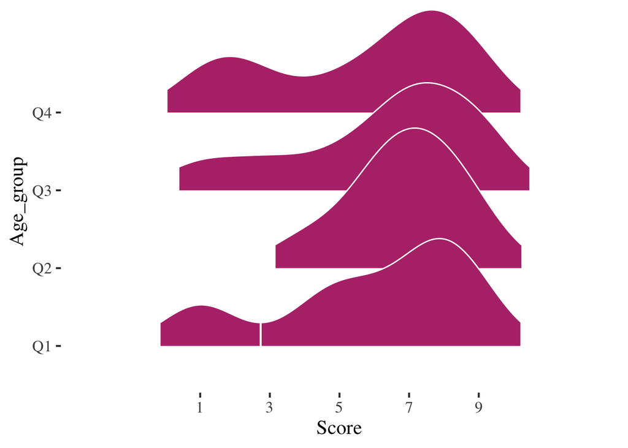

The picture isn’t completely clear, but perhaps with a larger study we could find out if older individuals are actually more picky with the biscuits that they choose to dunk.